# Lab Seven: RNN

### --Sixth Architecture--

Tuned hyperparameter: recurrent_dropout

We use GRU and changed recurrent_dropout to 0.8

```python
input_holder_comment = Input(shape=(X_train_comment.shape[1], ))
input_embed_comment = Embedding(top_words_comment, # input dimension (max int of OHE)
                60, # output dimension size
                input_length=60)(input_holder_comment) # number of words in each sequence

comment_x = GRU(60, dropout=0.6, recurrent_dropout=0.8,
                  name='comment_lstm')(input_embed_comment)

input_holder_parent_comment = Input(shape=(X_train_parent_comment.shape[1], ))
input_embed_parent_comment = Embedding(top_words_parent_comment, # input dimension (max int of OHE)
                200, # output dimension size
                input_length=200)(input_holder_parent_comment) # number of words in each sequence

parent_comment_x = GRU(200, dropout=0.6, recurrent_dropout=0.8,
                  name='parent_comment_lstm')(input_embed_parent_comment)


input_numeric=Input(shape=(X_train_num.shape[1],),sparse=False,name='numeric_data')

col='subreddit_int'
N = max(X_train_cat+1)
N=N[0]
input_cat = Input(shape=(1,),dtype='int32', name=col)
cat_x = Embedding(input_dim=N,
                  output_dim=int(np.sqrt(N)),
                  input_length=1, name=col+'_embed')(input_cat)
cat_x = Flatten()(cat_x)

x_2=concatenate([input_numeric,cat_x])
# x_2=Dense(30, activation='selu', name='2_dense')(x_2)

x_1 = concatenate([comment_x,parent_comment_x])
x_1 = Dense(40, activation='selu', name='emb_dense_1')(x_1)
x_1 = Dropout(0.6,seed=2)(x_1)
x_1 = Dense(30, activation='selu', name='emb_dense_2')(x_1)
x_1 = Dropout(0.6,seed=2)(x_1)
x = concatenate([x_2,x_1])

x = Dense(20, activation='selu', name='all_dense_1')(x)
x = Dropout(0.6,seed=2)(x)
x = Dense(10, activation='selu', name='all_dense_2')(x)
x = Dropout(0.6,seed=2)(x)
x = Dense(2, activation='sigmoid', name='outputt')(x)

rnn_6 = Model(inputs=[input_holder_comment,input_holder_parent_comment,input_numeric,input_cat], outputs=x)
```

```python
rnn_6.compile(loss='binary_crossentropy',
              optimizer='rmsprop',
              metrics=[precision_m])
```

```python
history_6=rnn_6.fit([X_train_comment,X_train_parent_comment,X_train_num,X_train_cat],
                    y_train_ohe, epochs=15, batch_size=2000,
                    validation_data=([X_test_comment,X_test_parent_comment,X_test_num,X_test_cat], y_test_ohe))
```

```
Train on 80141 samples, validate on 20036 samples
```

```python
yhat_6 = rnn_6.predict([X_test_comment,X_test_parent_comment,X_test_num,X_test_cat])
yhat_6=np.round(yhat_6)
yhat_6=np.argmax(yhat_6, axis=1)
precision_score_list.append(mt.precision_score(y_test,yhat_6))
print(mt.confusion_matrix(y_test,yhat_6),mt.precision_score(y_test,yhat_6))
print('Recall score is: ',mt.recall_score(y_test,yhat_6))
```

```
[[5529 4512]
 [2510 7485]] 0.6239059764941235
Recall score is:  0.7488744372186094
```

### --Seventh Architecture--

Looks like model 1 has the best performance so far. Now we add another recurrent chain to the network and see if that help with the performance

```python
input_holder_comment = Input(shape=(X_train_comment.shape[1], ))
input_embed_comment = Embedding(top_words_comment, # input dimension (max int of OHE)
                EMBED_SIZE, # output dimension size
                input_length=60)(input_holder_comment) # number of words in each sequence

comment_x = LSTM(60, dropout=0.6, recurrent_dropout=0.6, return_sequences=True,
                  name='comment_lstm')(input_embed_comment)


comment_x = LSTM(60,
                  name='comment_lstm_2')(comment_x)

input_holder_parent_comment = Input(shape=(X_train_parent_comment.shape[1], ))
input_embed_parent_comment = Embedding(top_words_parent_comment, # input dimension (max int of OHE)
                EMBED_SIZE, # output dimension size
                input_length=200)(input_holder_parent_comment) # number of words in each sequence

parent_comment_x = LSTM(200, dropout=0.6, recurrent_dropout=0.6, return_sequences=True,
                  name='parent_comment_lstm')(input_embed_parent_comment)

parent_comment_x = LSTM(200,
                  name='parent_comment_lstm_2')(parent_comment_x)


input_numeric=Input(shape=(X_train_num.shape[1],),sparse=False,name='numeric_data')

col='subreddit_int'
N = max(X_train_cat+1)
N=N[0]
input_cat = Input(shape=(1,),dtype='int32', name=col)
cat_x = Embedding(input_dim=N,
                  output_dim=int(np.sqrt(N)),
                  input_length=1, name=col+'_embed')(input_cat)
cat_x = Flatten()(cat_x)

x_2=concatenate([input_numeric,cat_x])
# x_2=Dense(30, activation='relu', name='2_dense')(x_2)

x_1 = concatenate([comment_x,parent_comment_x])
x_1 = Dense(40, activation='relu', name='emb_dense_1')(x_1)
x_1 = Dropout(0.6,seed=2)(x_1)
x_1 = Dense(30, activation='relu', name='emb_dense_2')(x_1)
x_1 = Dropout(0.6,seed=2)(x_1)
x = concatenate([x_2,x_1])

x = Dense(20, activation='relu', name='all_dense_1')(x)
x = Dropout(0.6,seed=2)(x)
x = Dense(10, activation='relu', name='all_dense_2')(x)
x = Dropout(0.6,seed=2)(x)
x = Dense(2, activation='sigmoid', name='outputt')(x)

rnn_7 = Model(inputs=[input_holder_comment,input_holder_parent_comment,input_numeric,input_cat], outputs=x)
```

```python
rnn_7.compile(loss='binary_crossentropy',
              optimizer='rmsprop',
              metrics=[precision_m])
```

```python
history_7=rnn_7.fit([X_train_comment,X_train_parent_comment,X_train_num,X_train_cat],
                    y_train_ohe, epochs=20, batch_size=2000,
                    validation_data=([X_test_comment,X_test_parent_comment,X_test_num,X_test_cat], y_test_ohe))
```

```
Train on 80141 samples, validate on 20036 samples
```

```python
yhat_7 = rnn_7.predict([X_test_comment,X_test_parent_comment,X_test_num,X_test_cat])
yhat_7=np.round(yhat_7)
yhat_7=np.argmax(yhat_7, axis=1)
precision_score_list.append(mt.precision_score(y_test,yhat_7))
print(mt.confusion_matrix(y_test,yhat_7),mt.precision_score(y_test,yhat_7))
print('Recall score is: ',mt.recall_score(y_test,yhat_7))
```

```
[[7588 2453]
 [4413 5582]] 0.6947106409458619
Recall score is:  0.5584792396198099
```

This model actually performs worse than the single LSTM layer model

All models' recall score (representing False Negative) look fine and are acceptable

### --Visualization--

Model 1: LSTM, Relu activation function, 0.6 recurrent dropout

Model 2: GRU, Relu activation function, 0.6 recurrent dropout

Model 3: LSTM, Selu activation function, 0.6 recurrent dropout

Model 4: GRU, Selu activation function, 0.6 recurrent dropout

Model 7: Two chains of LSTM, Relu activation function, 0.6 recurrent dropout

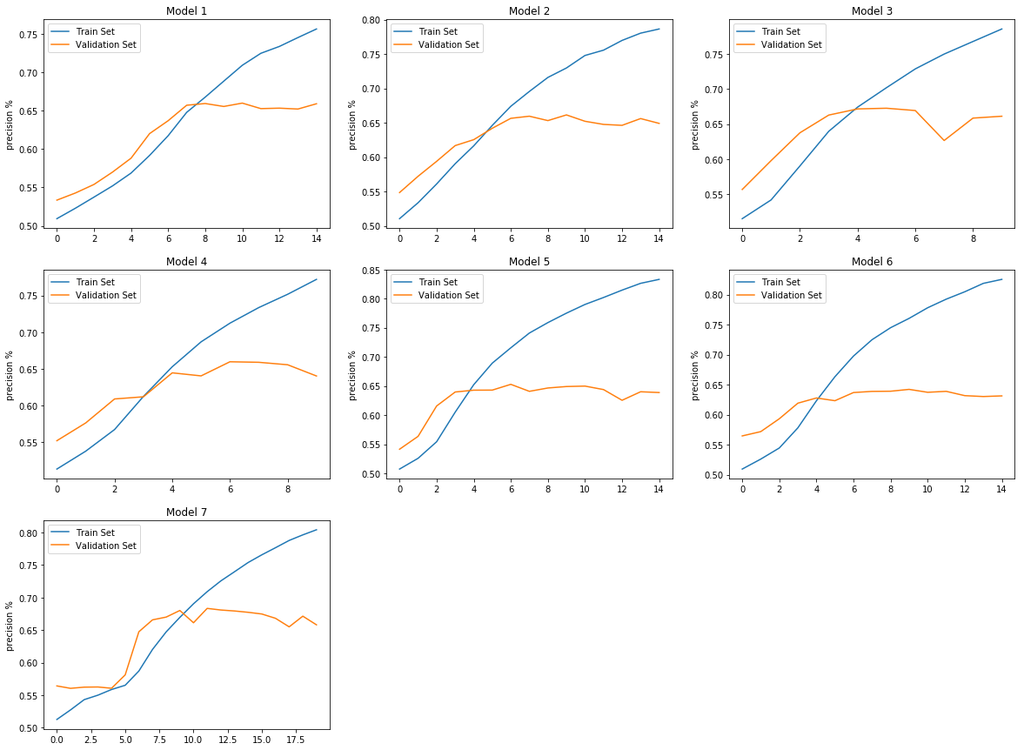

```python
%matplotlib inline
import matplotlib.pyplot as plt

plt.figure(figsize=(20,15))
plt.subplot(3, 3, 1)
plt.plot(history_1.history['precision_m'], label='Train Set')
plt.ylabel('precision %')
plt.title('Model 1')
plt.plot(history_1.history['val_precision_m'], label='Validation Set')
plt.legend()

plt.subplot(3, 3, 2)
plt.plot(history_2.history['precision_m'], label='Train Set')
plt.ylabel('precision %')
plt.title('Model 2')
plt.plot(history_2.history['val_precision_m'], label='Validation Set')
plt.legend()

plt.subplot(3, 3, 3)
plt.plot(history_3.history['precision_m'], label='Train Set')
plt.ylabel('precision %')
plt.title('Model 3')
plt.plot(history_3.history['val_precision_m'], label='Validation Set')
plt.legend()

plt.subplot(3, 3, 4)
plt.plot(history_4.history['precision_m'], label='Train Set')
plt.ylabel('precision %')
plt.title('Model 4')
plt.plot(history_4.history['val_precision_m'], label='Validation Set')
plt.legend()

plt.subplot(3, 3, 5)
plt.plot(history_5.history['precision_m'], label='Train Set')
plt.ylabel('precision %')
plt.title('Model 5')
plt.plot(history_5.history['val_precision_m'], label='Validation Set')
plt.legend()

plt.subplot(3, 3, 6)
plt.plot(history_6.history['precision_m'], label='Train Set')
plt.ylabel('precision %')
plt.title('Model 6')
plt.plot(history_6.history['val_precision_m'], label='Validation Set')
plt.legend()

plt.subplot(3, 3, 7)
plt.plot(history_7.history['precision_m'], label='Train Set')
plt.ylabel('precision %')
plt.title('Model 7')
plt.plot(history_7.history['val_precision_m'], label='Validation Set')
plt.legend()
```

Here our RNN models do not follow normal training trajectory. The training performance score keeps going up as epoch increases. The validation data score increases until the precision score reaches around 0.66 to 0.68. After that, the score just bounces up and down, I believe that Model 1,2,5,6 show signs of converging. Model 4 shows sign of decreasing performance as the model overtrains. Model 3 and Model 7's performances have a large fluctuation but basically are converging.

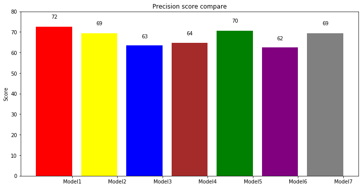

```python
method=['Model1','Model2','Model3','Model4','Model5','Model6','Model7']
precision_score_compare=np.array(precision_score_list)*100
import matplotlib.pyplot as plt

x = [0,1,2,3,4,5,6]
width = 0.8 # width of the bars

def autolabel(rects):
    # attach some text labels
    for rect in rects:
        height = rect.get_height()
        ax.text(rect.get_x() + rect.get_width()/2., 1.05*height,
                '%d' % float(height),
                ha='center', va='bottom')

fig, ax = plt.subplots(figsize=(12,6))
color=['red', 'yellow', 'blue', 'brown', 'green','purple','grey']
rects1 = ax.bar(x, precision_score_compare, width, color=color)

ax.set_ylim(0,80)
ax.set_ylabel('Score')
ax.set_title('Precision score compare')
ax.set_xticks(np.add(x,(width/2))) # set the position of the x ticks
ax.set_xticklabels(method)


autolabel(rects1)

plt.show()
```

## McNemar Test

We will use McNemar test to determine which method(s) is (are) superior. To do that, we need to first save all the prediction data into a csv file because ManeFrame II do not have the module 'mlxtend', which we will use to calculate p-value in McNemar test

```python
Big_data=[yhat_1,yhat_2,yhat_3,yhat_4,yhat_5,yhat_6,yhat_7,y_test]
df_pred=pd.DataFrame(Big_data)
df_pred.T.to_csv('pred_data.csv')
```

This is where my laptop picked up.

```python
df_pred = pd.read_csv('pred_data.csv')
df_pred = pd.DataFrame(df_pred.values,columns=['index','1','2','3','4','5','6','7','real'])
df_pred.head()
```

|  | index | 1 | 2 | 3 | 4 | 5 | 6 | 7 | real |
| --- | --- | --- | --- | --- | --- | --- | --- | --- | --- |
| 0 | 0 | 0 | 1 | 1 | 1 | 1 | 1 | 1 | 1 |
| 1 | 1 | 1 | 1 | 1 | 1 | 1 | 1 | 1 | 1 |
| 2 | 2 | 1 | 1 | 1 | 1 | 1 | 1 | 1 | 1 |
| 3 | 3 | 0 | 0 | 0 | 0 | 0 | 0 | 0 | 0 |
| 4 | 4 | 0 | 0 | 0 | 0 | 0 | 1 | 0 | 0 |

We will use mlxtend to calculate p-value, if p-value is lower than 0.05, then we can say these two models are statisically different

```python
from mlxtend.evaluate import mcnemar_table
import numpy as np
from mlxtend.evaluate import mcnemar

index=['1','2','3','4','5','6','7']

for i in index:
    for j in index:
        if j>i:
            tb = mcnemar_table(y_target=df_pred['real'],
                   y_model1=df_pred[i],
                   y_model2=df_pred[j])


            chi2, p = mcnemar(ary=tb, corrected=True)
            if(p<0.05):

                print('Model'+i+" vs Model"+j+" are statisitcally different by p value")

                print('chi-squared:', chi2)
                print('p-value:', p)
                print('------------------------')
```

```
Model1 vs Model2 are statisitcally different by p value
chi-squared: 31.14546225614928
p-value: 2.393983377727499e-08
------------------------
Model1 vs Model3 are statisitcally different by p value
chi-squared: 21.875667592394787
p-value: 2.9089926088317494e-06
------------------------
Model1 vs Model4 are statisitcally different by p value
chi-squared: 4.536969420356002
p-value: 0.033170268024954964
------------------------
Model1 vs Model5 are statisitcally different by p value
chi-squared: 19.361094038106945
p-value: 1.081888777755769e-05
------------------------
Model1 vs Model6 are statisitcally different by p value
chi-squared: 29.35726693688477
p-value: 6.019038041035026e-08
------------------------
Model1 vs Model7 are statisitcally different by p value
chi-squared: 25.559244419004006
p-value: 4.290057094661922e-07
------------------------
Model2 vs Model4 are statisitcally different by p value
chi-squared: 4.041039339485187
p-value: 0.04440646519699098
------------------------
Model3 vs Model4 are statisitcally different by p value
chi-squared: 12.5680285600952
p-value: 0.00039240230837951314
------------------------
Model4 vs Model6 are statisitcally different by p value
chi-squared: 17.136806910002786
p-value: 3.478169131305082e-05
------------------------
Model4 vs Model7 are statisitcally different by p value
chi-squared: 12.379965457685666
p-value: 0.0004339651788236066
------------------------
```

Looks like Model 1, statistically, are all different with other models. Checking the performance plot above, we find that model 1 has the best score over all other models. Therefore, we can say model 1 is superior.

## Extra I - - Text Generate

Let's see if we can build a model that can write text.

We will first take out all comments

```python
#The website below helps me with preprocessing the data
#https://machinelearningmastery.com/text-generation-lstm-recurrent-neural-networks-python-keras/

list1=df['comment'].values
text = ''.join(list1)

chars = sorted(list(set(text))) # getting all unique chars

print('total chars: ', len(chars))
char_indices = dict((c, i) for i, c in enumerate(chars))
indices_char = dict((i, c) for i, c in enumerate(chars))
maxlen = 40
step = 10
sentences = []
next_chars = []
for i in range(0, len(text) - maxlen, step):
    sentences.append(text[i: i + maxlen])
    next_chars.append(text[i + maxlen])
x = np.zeros((len(sentences), maxlen, len(chars)), dtype=np.bool)
y = np.zeros((len(sentences), len(chars)), dtype=np.bool)
for i, sentence in enumerate(sentences):
    for t, char in enumerate(sentence):
        x[i, t, char_indices[char]] = 1
    y[i, char_indices[next_chars[i]]] = 1
```

```
total chars:  93
```

Let's use CuDNNLSTM to speed up the process!

```python
from keras.models import Sequential
from keras.layers import Dense, Activation
from keras.layers import LSTM,CuDNNLSTM
model = Sequential()
model.add(CuDNNLSTM(256, input_shape=(maxlen, len(chars))))
model.add(Dropout(0.3))
model.add(Dense(len(chars),activation='relu'))
model.add(Activation('softmax'))
model.compile(loss='categorical_crossentropy', optimizer='rmsprop')
model.fit(x, y, batch_size=200, epochs=10)
```

```
<keras.callbacks.History at 0x2ab307dec160>
```

```python
Starting_Pattern="i am travis model that can write novel. i am trash. this is a padding to make sure the characters number exceed the limit. "
s=list(Starting_Pattern)
for i in range(500):
    x = np.zeros((1, maxlen, len(chars)), dtype=np.bool)
    for t, char in enumerate(s[-41:-1]):
        x[0, t, char_indices[char]] = 1
    next_char_cat=model.predict(np.array(x))
    next_char_int=np.random.choice(93,5, p=next_char_cat[0])

    nextnext=[]
    for j in range(len(next_char_int)):
        nextnext.append(next_char_cat[0][next_char_int[j]])

    next_int=np.argmax(nextnext)
    next_char_int=next_char_int[next_int]
#     print(next_char_int)
    next_char=indices_char[next_char_int]
    s.append(next_char)
print(''.join(s))
```

```
i am travis model that can write novel. i am trash. this is a padding to make sure the characters number exceed the limit. dwoerns  tahnn aanrye rtea rbeanr ian  twhoets  ainn tahlien  asn  garmeannteers  ainn  aanr eanrt itn osnt eamsb ltiyn  hiisteirn  tahl ewne rweaagna r"e~  aandya naomd atn etn…
```

We now use Jane Austen's Pride and Prejudice to train the model.

```python
import io
with io.open("Pride and Prejudice.txt", "r", encoding="ISO-8859-1") as my_file:
     my_unicode_string = my_file.read()
text= my_unicode_string.replace('\n','')
text=''.join(x for x in text if x.isalpha() or x==' ' or x==',' or x=='.')

chars = sorted(list(set(text)))

print('total chars: ', len(chars))
char_indices = dict((c, i) for i, c in enumerate(chars))
indices_char = dict((i, c) for i, c in enumerate(chars))
maxlen = 100
step = 4
sentences = []
next_chars = []
for i in range(0, len(text) - maxlen, step):
    sentences.append(text[i: i + maxlen])
    next_chars.append(text[i + maxlen])
x = np.zeros((len(sentences), maxlen, len(chars)), dtype=np.bool)
y = np.zeros((len(sentences), len(chars)), dtype=np.bool)
for i, sentence in enumerate(sentences):
    for t, char in enumerate(sentence):
        x[i, t, char_indices[char]] = 1
    y[i, char_indices[next_chars[i]]] = 1
```

```
total chars:  55
```

```python
from keras.models import Sequential
from keras.layers import Dense, Activation
from keras.layers import LSTM,CuDNNLSTM
model = Sequential()
model.add(CuDNNLSTM(256, input_shape=(maxlen, len(chars))))
model.add(Dropout(0.3))
model.add(Dense(len(chars),activation='relu'))
model.add(Activation('softmax'))
model.compile(loss='categorical_crossentropy', optimizer='rmsprop')
```

```python
model.fit(x, y, batch_size=200, epochs=20)
```

```
<keras.callbacks.History at 0x2ab17617ca20>
```

```python
Starting_Pattern="i am travis model that can write novel. i am trash. this is a padding to make sure the characters number exceed the limit. "
s=list(Starting_Pattern)
for i in range(500):
    x = np.zeros((1, maxlen, len(chars)), dtype=np.bool)
    for t, char in enumerate(s[-101:-1]):
        x[0, t, char_indices[char]] = 1
    next_char_cat=model.predict(np.array(x))
    next_char_int=np.random.choice(55,5, p=next_char_cat[0])

    nextnext=[]
    for j in range(len(next_char_int)):
        nextnext.append(next_char_cat[0][next_char_int[j]])
    next_int=np.argmax(nextnext)
    next_char_int=next_char_int[next_int]
    next_char=indices_char[next_char_int]
    s.append(next_char)

print(''.join(s))
```

```
i am travis model that can write novel. i am trash. this is a padding to make sure the characters number exceed the limit.  oounldi.e Nmeaatl ytou sdheerd oancdeed  thheer esvterde saoinsg,o nhoers  oafcteudse  tahlea tmoasg emset tto nfoirg etn etvheey  haavde dtoawdh eosfeuste diesd,e staalllyy ou…
```

Ok.....Let's give it another 20 epochs

```python
model.fit(x, y, batch_size=200, epochs=20)
```

```
<keras.callbacks.History at 0x2ab175f6fb38>
```

```python
Starting_Pattern="This novel was written by Jane Austen and it was a very popular one. Doctor Larson is very nice and handsome. "
s=list(Starting_Pattern)
for i in range(500):
    x = np.zeros((1, maxlen, len(chars)), dtype=np.bool)
    for t, char in enumerate(s[-101:-1]):
        x[0, t, char_indices[char]] = 1
    next_char_cat=model.predict(np.array(x))
    next_char_int=np.random.choice(55,5, p=next_char_cat[0])

    nextnext=[]
    for j in range(len(next_char_int)):
        nextnext.append(next_char_cat[0][next_char_int[j]])

    next_int=np.argmax(nextnext)
    next_char_int=next_char_int[next_int]
    next_char=indices_char[next_char_int]
    s.append(next_char)

print(''.join(s))
```

```
This novel was written by Jane Austen and it was a very popular one. Doctor Larson is very nice and handsome. qMuisss ecneieg  thheorse lfaotu rheamciendc haal  taoidn otf eilth eosbeetn,o nhoargeedd hte  sauist  sauisn eivterd  off eciont owf  liabdliyhsa ccrreimtarncee doowr  hwarreisneoss  twhoiu…
```

For some reason it cannot generate normal words. Probably we should add more LSTM in the recurrent network and give it more epochs can help improve it.

## --Extra II--

Use t-SNE (or SVD) to visualize the word embeddings of a subset of words in your vocabulary.

```python
for l in rnn_1.layers:
    print(l.name)
```

```
input_44
input_45
embedding_44
embedding_45
comment_lstm
parent_comment_lstm
concatenate_65
subreddit_int
emb_dense_1
subreddit_int_embed
dropout_137
numeric_data
flatten_22
emb_dense_2
concatenate_64
dropout_138
concatenate_66
all_dense_1
dropout_139
all_dense_2
dropout_140
outputt
```

```python
from sklearn.manifold import TSNE
tsne = TSNE(n_components=2, random_state=0)
np.set_printoptions(suppress=True)

w=rnn_1.layers[2].get_weights()[0]
weights = tsne.fit_transform(w)
weights
```

```
array([[-21.989439 , -14.832793 ],
       [-12.131962 ,  -7.8907657],
       [ -9.572989 ,  -9.936634 ],
       ...,
       [ 18.043118 ,   7.797022 ],
       [ 24.830269 ,   6.079445 ],
       [-15.913324 ,  -0.9319884]], dtype=float32)
```

TSNE took a very LONG time. What it does is lower down the dimension to 2 so that we can plot the weights of words.

Let's first try to visualize some relating words and see if our training model can make analogy.

```python
words=['china','chinese','korea','korean','japan','japanese','german','germany','america','american']
word_array=[]
for i in words:
    word_array.append(word_index[i])
```

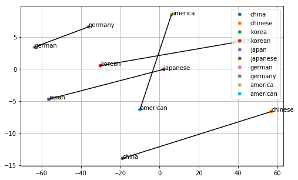

```python
fig, ax = plt.subplots(figsize=(8,5))
cm = plt.get_cmap('gist_rainbow')
for i in range(0,len(words)):
    ax.scatter(weights[ word_array[i]][0],weights[ word_array[i]][1],label=words[i],
               alpha=1, edgecolors='none')
for i in range(0, len(words), 2):
    plt.plot([weights[ word_array[i]][0],weights[ word_array[i+1]][0]],[weights[ word_array[i]][1],weights[ word_array[i+1]][1]],'k-')

for i, txt in enumerate(words):
    ax.annotate(txt, (weights[word_array[i]][0], weights[word_array[i]][1]))
ax.legend()
ax.grid(True)

plt.show()
```

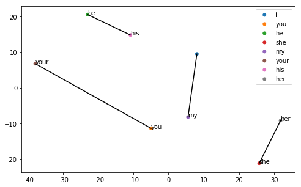

```python
words=['i','you','he','she','my','your','his','her']
word_array=[]
for i in words:
    word_array.append(word_index[i])

fig, ax = plt.subplots(figsize=(8,5))
for i in range(0,len(words)):
    ax.scatter(weights[ word_array[i]][0],weights[ word_array[i]][1],label=words[i],
               alpha=1, edgecolors='none')
for i in range(0, int(len(words)/2)):
    plt.plot([weights[ word_array[i]][0],weights[ word_array[i+4]][0]],[weights[ word_array[i]][1],weights[ word_array[i+4]][1]],'k-')
for i, txt in enumerate(words):
    ax.annotate(txt, (weights[word_array[i]][0], weights[word_array[i]][1]))
ax.legend()
```

This does not look like the training model find a pattern. Maybe our model is not sensitive with this pattern. Let's do more and see if we can find anything interesting

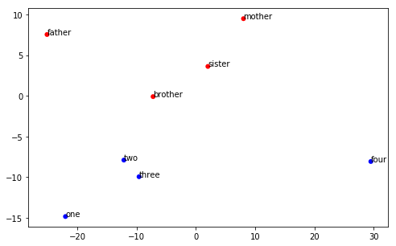

```python
words=['one','two','three','four','mother','father','sister','brother']
word_array=[]
for i in words:
    word_array.append(word_index[i])

fig, ax = plt.subplots(figsize=(8,5))
for i in range(0,int(len(words)/2)):
    ax.scatter(weights[ word_array[i]][0],weights[ word_array[i]][1],label=words[i],color='blue',
               alpha=1, edgecolors='none')
for i in range(int(len(words)/2),int(len(words))):
    ax.scatter(weights[ word_array[i]][0],weights[ word_array[i]][1],label=words[i],color='red',
               alpha=1, edgecolors='none')
for i, txt in enumerate(words):
    ax.annotate(txt, (weights[word_array[i]][0], weights[word_array[i]][1]))
```

There is a clear boundary between two groups. For x-axis, we are suprised to find out that it follows the order of 'one'-'two'-'three'-'four'

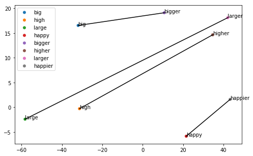

```python
words=['big','high','large','happy','bigger','higher','larger','happier']
word_array=[]
for i in words:
    word_array.append(word_index[i])

fig, ax = plt.subplots(figsize=(8,5))
for i in range(0,len(words)):
    ax.scatter(weights[ word_array[i]][0],weights[ word_array[i]][1],label=words[i],
               alpha=1, edgecolors='none')
for i in range(0, int(len(words)/2)):
    plt.plot([weights[ word_array[i]][0],weights[ word_array[i+4]][0]],[weights[ word_array[i]][1],weights[ word_array[i+4]][1]],'k-')
for i, txt in enumerate(words):
    ax.annotate(txt, (weights[word_array[i]][0], weights[word_array[i]][1]))
ax.legend()
```

There is a clear pattern as the comparative adjective is always on the top right of the adjective itself. Y-axis might repesent comparative degree